# R的描述统计

李峰

三月 29, 2017

### 1. 数值型单变量描述

#### 1.1 基本描述统计

- 一个变量的描述统计

使用**summary(数据对象名)**函数

```r
attach(ReportCard)
(Av.Poli<-mean(poli))
```

```
## [1] NA
```

```r
(Av.Poli<-mean(poli,na.rm=TRUE))
```

```
## [1] 79.63793
```

```r
(Sd.Poli<-sd(poli,na.rm=TRUE))
```

```
## [1] 10.57587
```

```r
(N<-length(poli[!is.na(poli)]))
```

```
## [1] 58
```

```r
summary(poli)
```

```
##    Min. 1st Qu.  Median    Mean 3rd Qu.    Max.    NA's
##   40.00   74.50   82.50   79.64   87.00   96.00       2
```

```r
detach(ReportCard)
```

绘制boxplot

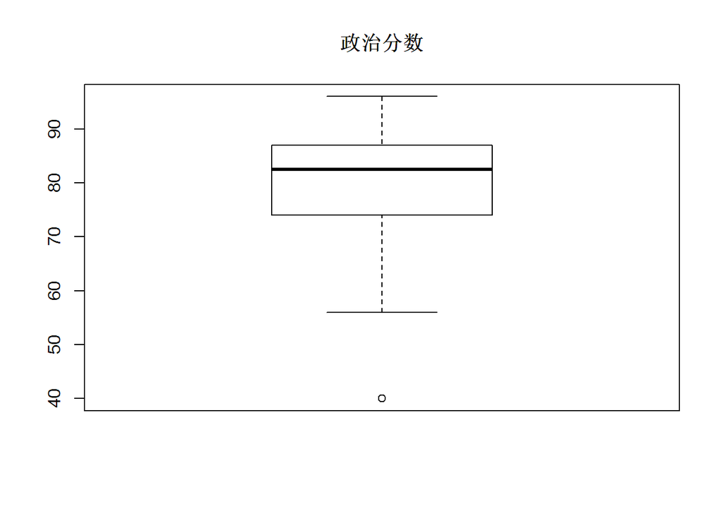

```r
boxplot(ReportCard$poli,horizontal=FALSE,main="政治分数")
```

绘制基于频数的histogram

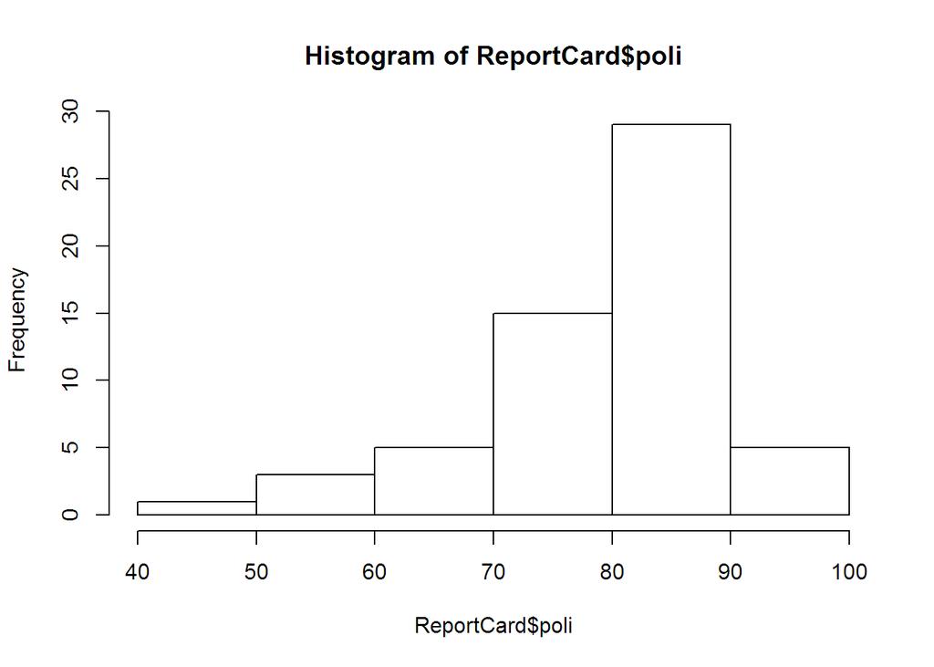

```r
hist(ReportCard$poli)
```

绘制基于比例的histogram

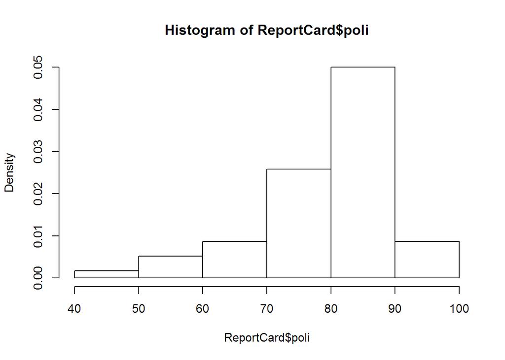

```r
hist(ReportCard$poli,freq=FALSE)
```

绘制基于比例的、有轴标签和图名的histogram

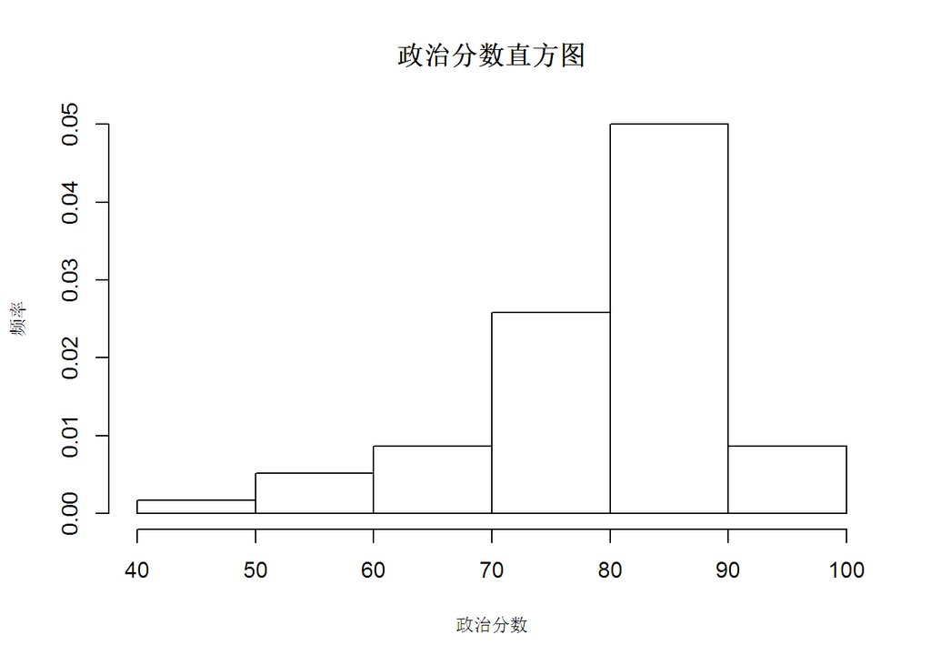

```r
hist(ReportCard$poli,xlab="政治分数",ylab="频率",main="政治分数直方图",
     cex.lab=0.8,freq=FALSE,ylim=c(0,0.05))
```

*cex.lab*定义轴标签字体大小。

*ylim*定义y轴区间。

在histgram上加正态分布图

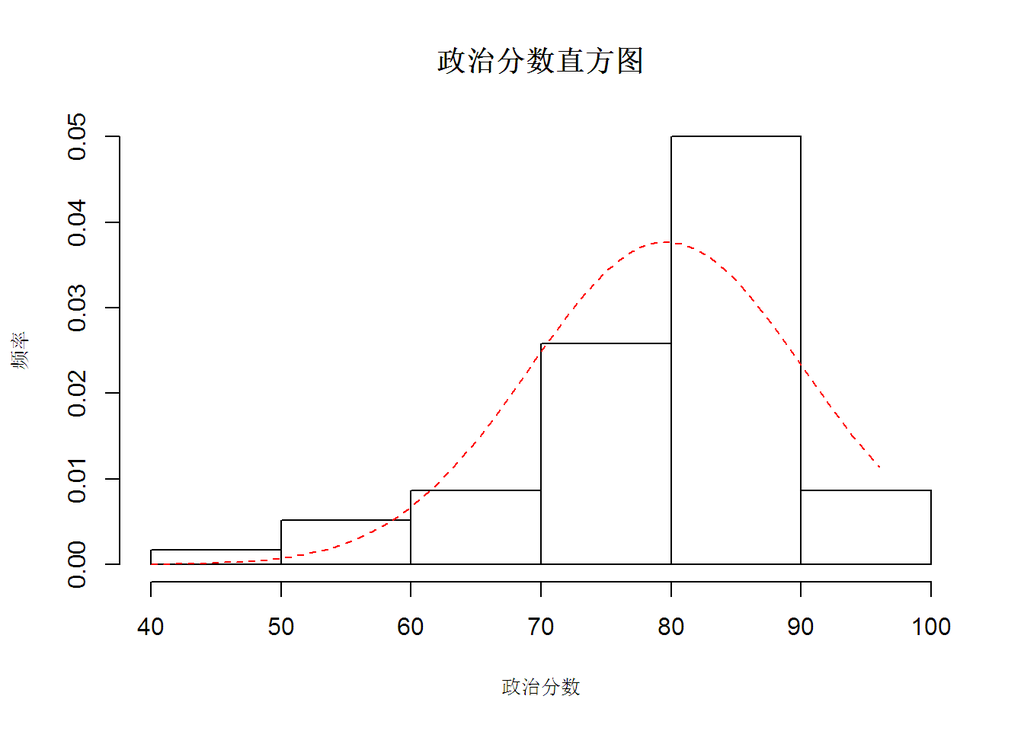

```r
Meanpoli=mean(ReportCard$poli,na.rm=TRUE)
Sdpoli=sd(ReportCard$poli,na.rm=TRUE)
d=seq(from=min(ReportCard$poli,na.rm=TRUE),to=max(ReportCard$poli,na.rm=TRUE),by=1)
hist(ReportCard$poli,xlab="政治分数",ylab="频率",main="政治分数直方图",
     cex.lab=0.8,freq=FALSE,ylim=c(0,0.05))
lines(x=d,y=dnorm(d,Meanpoli,Sdpoli),lty=2,col=2)
```

*lty*定义线形，2是虚线。

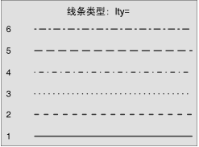

*col*定义颜色，调色板中的索引。R中用palette()表示调色板，默认的是颜色是下面的几种，在默认情况下，col=2表示红色。这个颜色会重复利用，如指定col=10同样是红色。

```r
palette()
```

```
## [1] "black"   "red"     "green3"  "blue"    "cyan"    "magenta" "yellow"
## [8] "gray"
```

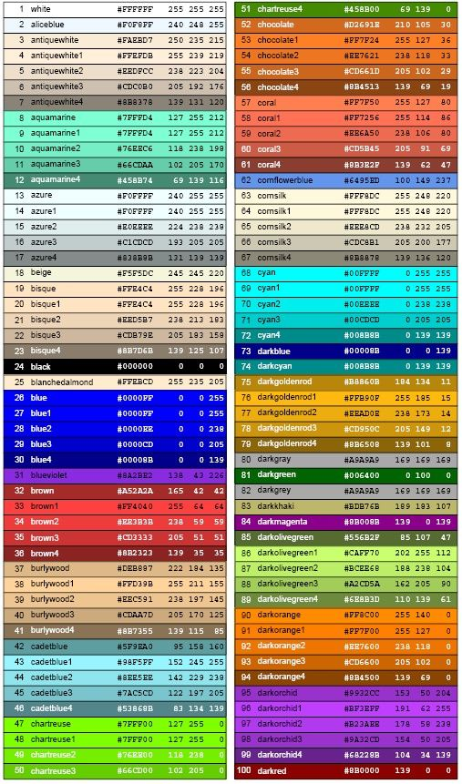

在histgram和正态分布图之上加核密度函数曲线

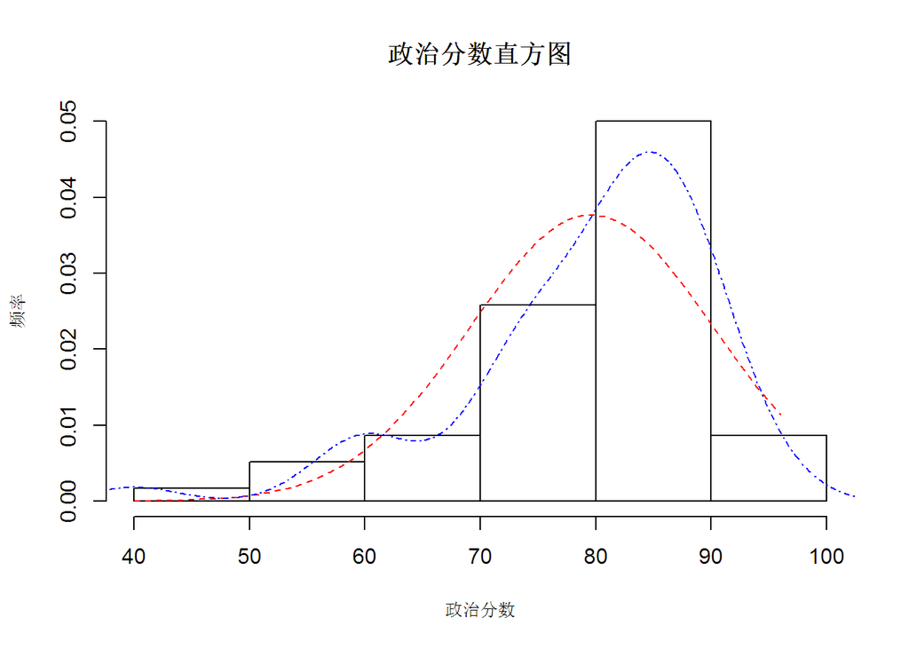

```r
hist(ReportCard$poli,xlab="政治分数",ylab="频率",main="政治分数直方图",
     cex.lab=0.8,freq=FALSE,ylim=c(0,0.05))
lines(x=d,y=dnorm(d,Meanpoli,Sdpoli),lty=2,col=2)
lines(density(ReportCard$poli,na.rm=TRUE),lty=4,col=4)
```

单独显示核密度函数曲线

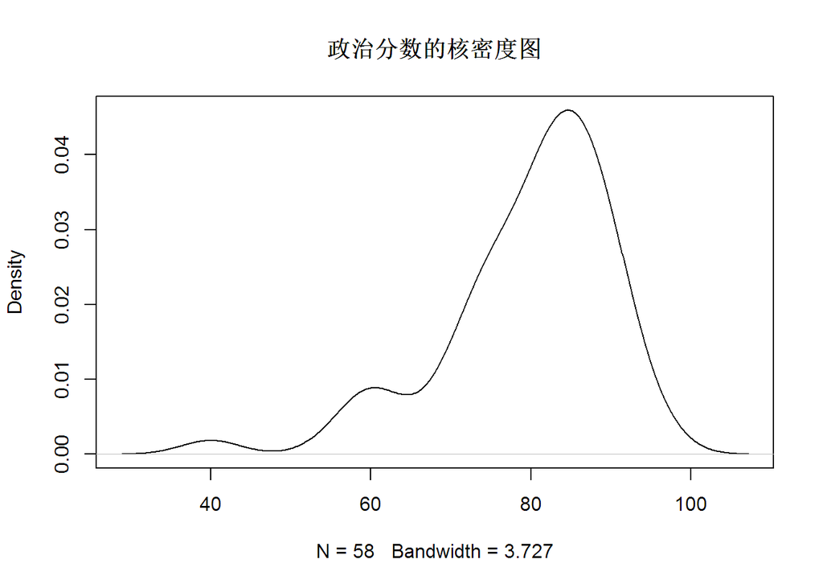

```r
plot(density(ReportCard$poli,na.rm=TRUE),main="政治分数的核密度图")
```

可以通过图形控制显示多个图

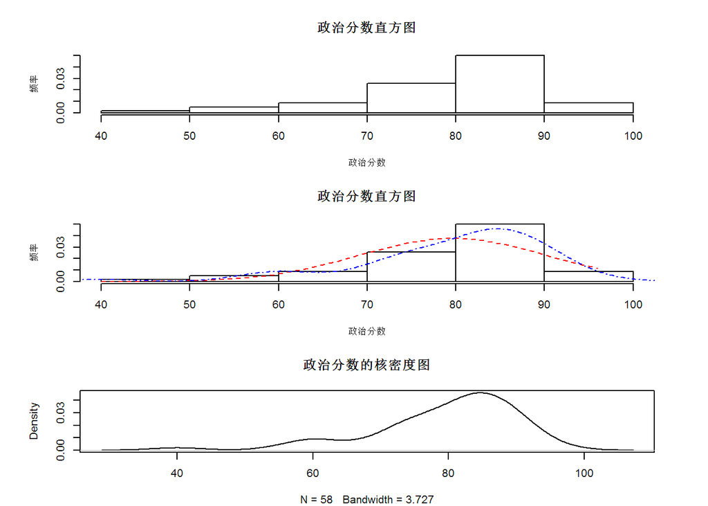

```r
DrawL<-par(no.readonly = TRUE)
par(mfrow=c(3,1),mar=c(4,6,4,4))
hist(ReportCard$poli,xlab="政治分数",ylab="频率",main="政治分数直方图",
     cex.lab=0.8,freq=FALSE,ylim=c(0,0.05))
Meanpoli=mean(ReportCard$poli,na.rm=TRUE)
Sdpoli=sd(ReportCard$poli,na.rm=TRUE)
d=seq(from=min(ReportCard$poli,na.rm=TRUE),to=max(ReportCard$poli,na.rm=TRUE),by=1)
hist(ReportCard$poli,xlab="政治分数",ylab="频率",main="政治分数直方图",
     cex.lab=0.8,freq=FALSE,ylim=c(0,0.05))
lines(x=d,y=dnorm(d,Meanpoli,Sdpoli),lty=2,col=2)
lines(density(ReportCard$poli,na.rm=TRUE),lty=4,col=4)
plot(density(ReportCard$poli,na.rm=TRUE),main="政治分数的核密度图")
```

```r
par(DrawL)
```

也可利用*psych*包计算描述统计量，全覆盖

```r
# install.packages("psych")
library("psych")
describe(ReportCard$poli)
```

```
##    vars  n  mean    sd median trimmed  mad min max range  skew kurtosis
## X1    1 58 79.64 10.58   82.5   80.81 8.15  40  96    56 -1.31     2.05
##      se
## X1 1.39
```

- 多个变量的描述统计

```r
(Av.Course<-sapply(ReportCard[,3:10],FUN=mean,na.rm=TRUE))
```

```
##     poli      chi     math     fore      phy      che      geo      his
## 79.63793 83.27966 61.16949 49.91667 75.20000 54.08333 65.24167 78.68333
```

```r
(Sd.Course<-sapply(ReportCard[,3:10],FUN=sd,na.rm=TRUE))
```

```
##      poli       chi      math      fore       phy       che       geo
## 10.575872  8.127365 15.076417 14.018501 12.351902 12.315474 15.394389
##       his
## 12.735233
```

为多个变量绘制核密度函数曲线

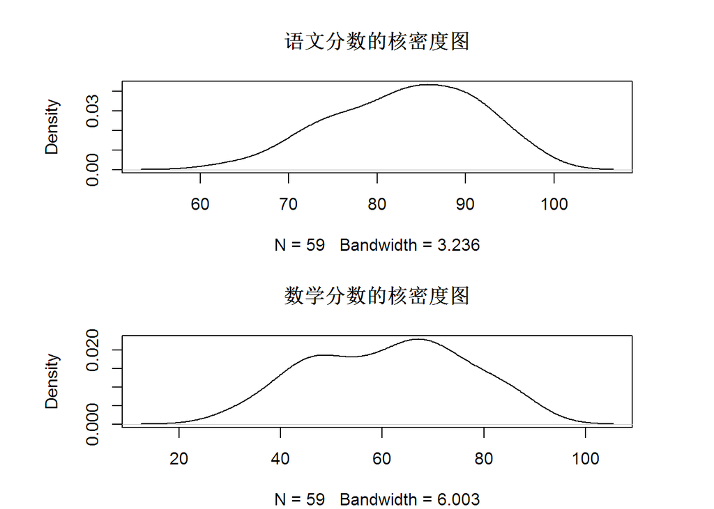

```r
Draw<-par(no.readonly = TRUE)
par(mfrow=c(2,1),mar=c(4,6,4,4))
plot(density(ReportCard$chi,na.rm=TRUE),main="语文分数的核密度图")
plot(density(ReportCard$math,na.rm=TRUE),main="数学分数的核密度图")
```

```r
par(Draw)
```

计算每门课程的平均分和总分

```r
(Av.Course<-colMeans(ReportCard[,3:10],na.rm=TRUE))
```

```
##     poli      chi     math     fore      phy      che      geo      his
## 79.63793 83.27966 61.16949 49.91667 75.20000 54.08333 65.24167 78.68333
```

```r
(Sum.Course<-colSums(ReportCard[,3:10],na.rm=TRUE))
```

```
##   poli    chi   math   fore    phy    che    geo    his
## 4619.0 4913.5 3609.0 2995.0 4512.0 3245.0 3914.5 4721.0
```

计算每个同学的平均分和总分

```r
Av.Person<-rowMeans(ReportCard[,3:10],na.rm=TRUE)
Sum.Person<-rowSums(ReportCard[,3:10],na.rm=TRUE)
```

- 多个变量的多个描述统计

计算每门课程的描述统计量（用户自定义函数的定义和调用）

```r
Des.Fun<-function(x,...){
 Av<-mean(x,na.rm=TRUE)
 Sd<-sd(x,na.rm=TRUE)
 N<-length(x[!is.na(x)])
 Sk<-sum((x[!is.na(x)]-Av)^3/Sd^3)/N
 Ku<-sum((x[!is.na(x)]-Av)^4/Sd^4)/N-3
 result<-list(avg=Av,sd=Sd,skew=Sk,kurt=Ku)
 return(result)
}
(DesRep<-sapply(ReportCard[,3:10],FUN=Des.Fun,na.rm=TRUE)) # 函数体也可以传递
```

```
##      poli      chi        math        fore        phy        che
## avg  79.63793  83.27966   61.16949    49.91667    75.2       54.08333
## sd   10.57587  8.127365   15.07642    14.0185     12.3519    12.31547
## skew -1.306537 -0.3117055 -0.07276131 -0.02902908 -0.3264613 -0.1116243
## kurt 2.053688  -0.6558917 -1.004213   -0.1879948  -0.7166125 -0.2767491
##      geo        his
## avg  65.24167   78.68333
## sd   15.39439   12.73523
## skew -0.8644448 -0.4610922
## kurt 0.07934935 -0.6362816
```

#### 1.2 分组描述统计

```r
MaleCard<-subset(ReportCard,ReportCard$sex=="M")
(Des.Male<-sapply(MaleCard[3:10],FUN=Des.Fun,na.rm=TRUE))
```

```
##      poli       chi        math       fore       phy        che
## avg  78.86667   83.5       60.03333   51.2       72.73333   52.36667
## sd   10.41793   6.874491   14.70276   13.12381   12.18516   11.39111
## skew -0.6431142 -0.1395905 -0.2319195 -0.2290347 -0.3062211 0.05773828
## kurt -0.639428  -0.8433017 -0.7633507 -0.1874488 -0.9496199 -0.8837325
##      geo        his
## avg  62.53333   78.93333
## sd   14.46275   12.67888
## skew -0.7055209 -0.4779689
## kurt -0.5034247 -0.6771532
```

```r
FeMaleCard<-subset(ReportCard,ReportCard$sex=="F")
(Des.FeMale<-sapply(FeMaleCard[3:10],FUN=Des.Fun,na.rm=TRUE))
```

```
##      poli      chi        math       fore       phy        che
## avg  80.46429  83.05172   62.34483   48.63333   77.66667   55.8
## sd   10.87124  9.368779   15.62456   14.97235   12.2202    13.14219
## skew -1.902856 -0.3244646 0.04216853 0.1641807  -0.3740188 -0.3155299
## kurt 4.587466  -0.9773456 -1.426078  -0.3044857 -0.6778506 0.01619171
##      geo       his
## avg  67.95     78.43333
## sd   16.05612  13.00314
## skew -1.100453 -0.4205089
## kurt 0.6549478 -0.7524053
```

```r
Des.Sex<-cbind(Des.Male,Des.FeMale)
```

```r
(Des.Gender<-tapply(ReportCard$poli,INDEX=ReportCard$sex,FUN=Des.Fun,na.rm=TRUE))
```

```
## $F
## $F$avg
## [1] 80.46429
##
## $F$sd
## [1] 10.87124
##
## $F$skew
## [1] -1.902856
##
## $F$kurt
## [1] 4.587466
##
##
## $M
## $M$avg
## [1] 78.86667
##
## $M$sd
## [1] 10.41793
##
## $M$skew
## [1] -0.6431142
##
## $M$kurt
## [1] -0.639428
```

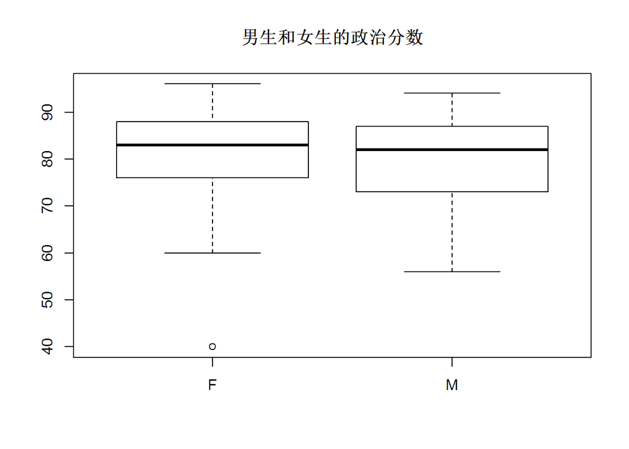

```r
boxplot(poli~sex,data=ReportCard,main="男生和女生的政治分数")
```

### 2. 分类型单变量描述

```r
(avFreTable<-table(ReportCard$avScore))
```

```
##
##  B  C  D  E
##  4 24 22  8
```

```r
prop.table(avFreTable)
```

```
##
##          B          C          D          E
## 0.06896552 0.41379310 0.37931034 0.13793103
```

```r
prop.table(avFreTable)*100
```

```
##
##         B         C         D         E
##  6.896552 41.379310 37.931034 13.793103
```

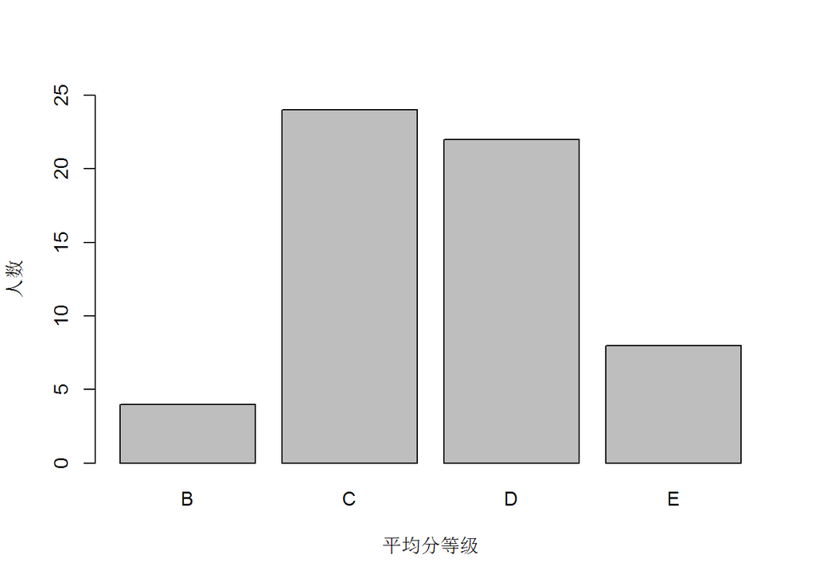

```r
NumGrade<-tapply(ReportCard$avScore,INDEX=ReportCard$avScore,FUN=length)
barplot(NumGrade,xlab="平均分等级",ylab="人数",ylim=c(0,25))
```

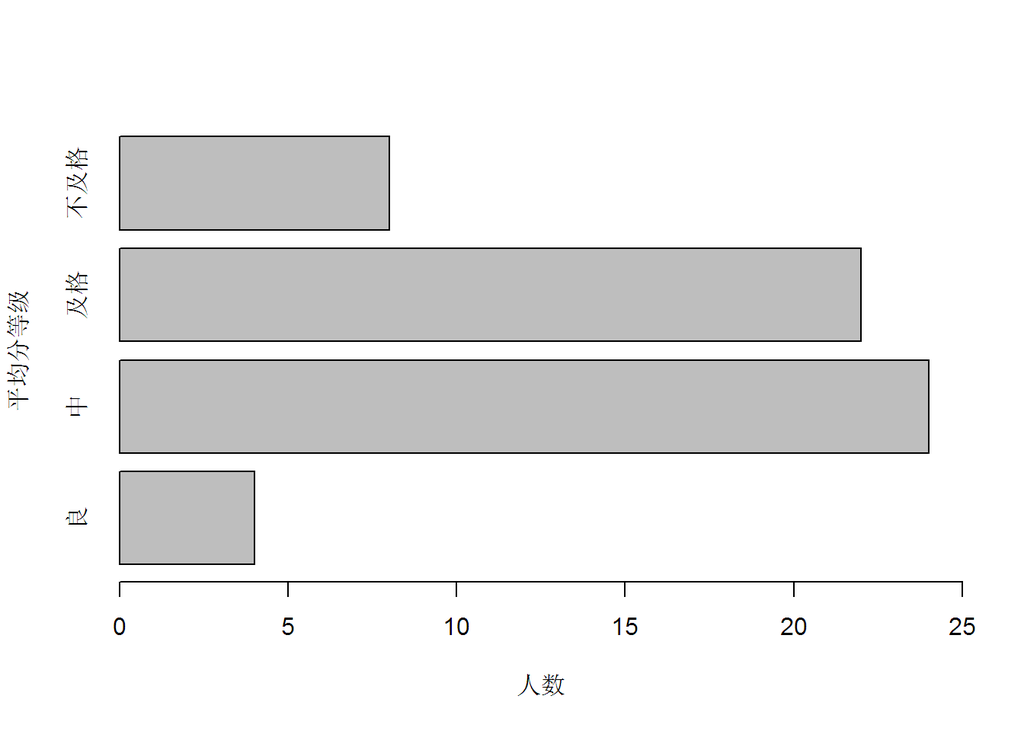

```r
barplot(NumGrade,ylab="平均分等级",xlab="人数",xlim=c(0,25),horiz=TRUE,names.arg=c("良","中","及格","不及格"))
```